# Functional Data Analysis: Electricity Demand Forecasting (Single Location)

## Overview

This notebook fits a function-on-function regression model to predict 24-hour electricity demand curves for **a single UK city**, selected by the user via the `loc_study` parameter below. The model uses:

- **Lagged demand** — the demand curve from exactly 7 days prior (captures weekly habitual patterns)
- **Temperature** and **wind speed** — daily weather curves
- **Activity** — a measure of population activity through the day

The model is fit using `pffr()` from the `refund` package, which extends generalised additive models to functional responses. Each functional covariate enters via `ffpc()`, which performs an internal functional PCA and uses the leading principal component scores as the effective predictors — this avoids estimating a full bivariate coefficient surface and keeps the model identifiable given the sample size.

```r
library(dplyr)
library(tidyr)
library(tidyverse)
library(lubridate)
library(ggplot2)
library(fda)
library(refund)
```

## 1. Load data

Expects a long-format CSV with one row per `date` x `location` x `hour`, and columns: `demand`, `temperature`, `wind_speed`, `activity`.

**To change which city is modelled, edit `loc_study` below** — it must match one of the values in the `location` column of `data.csv` exactly (case-sensitive).

```r
set.seed(42)

# ---- Parameters -------------------------------------------------------
loc_study    <- "swansea"   # <<< CHANGE THIS to model a different city
                                #     e.g. "bristol", "cardiff", "derby", "swansea"

n_hours      <- 24
t_grid       <- 1:n_hours      # hourly evaluation grid (1 = 00:00-01:00, ..., 24 = 23:00-00:00)
period       <- 24             # Fourier basis period (daily cycle)
lag_days     <- 7              # number of days to lag demand by (captures weekly habit)
train_prop   <- 0.8            # proportion of days used for training (chronological split)
nbasis_cands <- c(5, 7, 9, 11, 13, 15)  # candidate Fourier basis sizes for CV (must be odd)

df_long <- read_csv("data.csv") |>
  mutate(date = as.Date(date)) |>
  filter(location == loc_study) |>     # restrict to the chosen city immediately
  arrange(date, hour)

if (nrow(df_long) == 0) {
  stop(sprintf("No rows found for loc_study = '%s' — check spelling against data.csv.", loc_study))
}

cat(sprintf("Modelling location: %s\n", loc_study))
```

```
Modelling location: swansea
```

## 2. Reshape to a single n_days x 24 matrix per variable

Data is pivoted from long format (one row per hour) into a wide `n_days x 24` matrix, one matrix per variable. This is the format `fda`/`refund` expect: each row is a discretised functional observation.

```r
# Extracts an (n_days x 24) matrix for the chosen location and one variable
extract_mat <- function(variable) {
  df_long |>
    dplyr::select(date, hour, dplyr::all_of(variable)) |>
    tidyr::pivot_wider(names_from = hour, values_from = dplyr::all_of(variable)) |>
    dplyr::arrange(date) |>
    tibble::column_to_rownames("date") |>
    as.matrix()
}

dates_all <- df_long |> arrange(date) |> distinct(date) |> pull(date)

demand_mat   <- extract_mat("demand")
temp_mat_all <- extract_mat("temperature")
wind_mat_all <- extract_mat("wind_speed")
act_mat_all  <- extract_mat("activity")
```

## 3. Define valid rows (account for the 7-day lag)

The first `lag_days` rows have no valid lagged demand curve and are excluded from modelling.

```r
n_days      <- nrow(demand_mat)
valid_rows  <- (lag_days + 1):n_days
n_valid     <- length(valid_rows)
dates_valid <- dates_all[valid_rows]
```

## 4. Select Fourier basis size via cross-validation

Demand has a strong daily (24-hour) periodicity, so a Fourier basis is the natural choice for smoothing. The number of basis functions controls the flexibility of the smoothed curves — too few oversmooths the daily profile, too many overfits noise. CV is performed using a simple linear lagged-demand predictor as a proxy, with an inner train/validation split.

```r
cat("Cross-validating Fourier basis order...\n")
```

```
Cross-validating Fourier basis order...
```

```r
n_train_cv <- floor(n_valid * train_prop)

Y_cv    <- demand_mat[valid_rows, ]
Ylag_cv <- demand_mat[(valid_rows - lag_days), ]
rownames(Y_cv)    <- NULL
rownames(Ylag_cv) <- NULL

cv_mse <- setNames(numeric(length(nbasis_cands)), nbasis_cands)

for (nb in nbasis_cands) {
  fbasis_cv <- create.fourier.basis(rangeval = c(1, 24), nbasis = nb, period = period)

  n_inner   <- floor(n_train_cv * 0.8)
  idx_inner <- 1:n_inner
  idx_outer <- (n_inner + 1):n_train_cv

  Y_in    <- smooth.basis(t_grid, t(Y_cv[idx_inner, ]),    fbasis_cv)$fd
  Ylag_in <- smooth.basis(t_grid, t(Ylag_cv[idx_inner, ]), fbasis_cv)$fd

  # Solve for the linear map Ylag -> Y in basis-coefficient space
  C_Y    <- inprod(Y_in, Y_in)
  C_YL   <- inprod(Ylag_in, Y_in)
  beta_c <- tryCatch(solve(C_Y, C_YL), error = function(e) NULL)
  if (is.null(beta_c)) { cv_mse[as.character(nb)] <- Inf; next }

  Ylag_out <- smooth.basis(t_grid, t(Ylag_cv[idx_outer, ]), fbasis_cv)$fd
  Y_pred   <- eval.fd(t_grid, Ylag_out) %*% beta_c
  cv_mse[as.character(nb)] <- mean((Y_pred - Y_cv[idx_outer, ])^2, na.rm = TRUE)

  cat(sprintf("  nbasis = %2d   CV MSE = %.4f\n", nb, cv_mse[as.character(nb)]))
}

best_nbasis <- as.integer(names(which.min(cv_mse)))
cat(sprintf("Selected nbasis = %d\n\n", best_nbasis))
```

[output not shown]

```r
fbasis <- create.fourier.basis(rangeval = c(1, 24), nbasis = best_nbasis, period = period)
```

## 5. Train / test split (chronological)

The split is chronological rather than random, since demand is a time series and random shuffling would let the model “see the future” during training via adjacent days.

```r
n_train     <- floor(n_valid * train_prop)
n_test      <- n_valid - n_train
idx_test    <- (n_train + 1):n_valid
dates_train <- dates_valid[1:n_train]
dates_test  <- dates_valid[idx_test]

cat(sprintf("Train: %d days (%s to %s)\n", n_train, min(dates_train), max(dates_train)))
```

```
Train: 213 days (2025-09-08 to 2026-04-08)
```

```r
cat(sprintf("Test:  %d days (%s to %s)\n", n_test,  min(dates_test),  max(dates_test)))
```

```
Test:  54 days (2026-04-09 to 2026-06-01)
```

## 6. Build model-ready matrices

Subsets each variable’s matrix to the training/test row indices. No `location` factor is needed now, since only one city is being modelled.

```r
clean_mat <- function(m) matrix(as.numeric(m), nrow = nrow(m), ncol = ncol(m))

build_matrices <- function(row_idx) {
  rows     <- valid_rows[row_idx]
  rows_lag <- rows - lag_days

  list(
    Y        = demand_mat[rows, ],
    Y_lag    = demand_mat[rows_lag, ],
    temp     = temp_mat_all[rows, ],
    wind     = wind_mat_all[rows, ],
    activity = act_mat_all[rows, ]
  )
}

train_data <- build_matrices(1:n_train)
test_data  <- build_matrices(idx_test)
```

## 7. Fit the function-on-function model

Model specification (single location, so no `location` term):

$$Y_i(t) = \beta_0(t) +
\sum_{k=1}^{13}\!f_k^{Y}(\xi^{Y}_{ik}, t)
+ \sum_{k=1}^{5}\!f_k^{T}(\xi^{T}_{ik}, t)
+ \sum_{k=1}^{5}\!f_k^{W}(\xi^{W}_{ik}, t)
+ \sum_{k=1}^{13}\!f_k^{A}(\xi^{A}_{ik}, t) +
\varepsilon_i(t)$$

where $\xi^{X}_{ik}$ are the functional principal component scores of covariate $X$ for observation $i$, automatically computed inside `ffpc()`. `npc.max` caps the number of components retained per covariate.

```r
cat(sprintf("Fitting pffr model for %s...\n", loc_study))
```

```
Fitting pffr model for swansea...
```

```r
fit <- pffr(
  Y ~ ffpc(Y_lag,     npc.max = 13) +   # lagged demand (weekly habit)
      ffpc(temp_mean, npc.max = 5)  +   # temperature
      ffpc(wind_mean, npc.max = 5)  +   # wind speed
      ffpc(activity,  npc.max = 13),    # activity profile
  data = list(
    Y         = clean_mat(train_data$Y),
    Y_lag     = clean_mat(train_data$Y_lag),
    temp_mean = clean_mat(train_data$temp),
    wind_mean = clean_mat(train_data$wind),
    activity  = clean_mat(train_data$activity)
  ),
  sandwich = "none"   # use standard (non-robust) covariance; clustering not needed here
)

cat("Model fitted.\n")
```

```
Model fitted.
```

```r
print(summary(fit))
```

```
Family: gaussian
Link function: identity

Formula:
Y ~ ffpc(Y_lag, npc.max = 13) + ffpc(temp_mean, npc.max = 5) +
    ffpc(wind_mean, npc.max = 5) + ffpc(activity, npc.max = 13)

Constant coefficients:
            Estimate Std. Error t value Pr(>|t|)
(Intercept)  338.097      6.669    50.7   <2e-16 ***
---
Signif. codes:  0 ‘***’ 0.001 ‘**’ 0.01 ‘*’ 0.05 ‘.’ 0.1 ‘ ’ 1

Smooth terms & functional coefficients:
                     edf Ref.df       F  p-value
Intercept(yindex) 14.691 19.000  24.895  < 2e-16 ***
ffpc(Y_lag)1       5.994  6.526  19.916  < 2e-16 ***
ffpc(Y_lag)2       5.190  5.859   3.690 0.000922 ***
ffpc(Y_lag)3       4.981  5.689   6.141 6.73e-06 ***
ffpc(Y_lag)4       4.176  4.967   3.262 0.005047 **
ffpc(Y_lag)5       3.894  4.689   1.552 0.165170
ffpc(Y_lag)6       3.387  4.155   1.442 0.181219
ffpc(Y_lag)7       2.821  3.526   5.859 0.000537 ***
ffpc(Y_lag)8       2.621  3.295   6.704 9.82e-05 ***
ffpc(Y_lag)9       2.443  3.084   4.485 0.003597 **
ffpc(Y_lag)10      2.224  2.815   2.963 0.035167 *
ffpc(Y_lag)11      2.351  2.974   7.847 3.64e-05 ***
ffpc(Y_lag)12      2.094  2.654   2.966 0.038537 *
ffpc(Y_lag)13      2.039  2.591  15.808  < 2e-16 ***
ffpc(temp_mean)1   7.793  7.976  34.245  < 2e-16 ***
ffpc(temp_mean)2   6.699  7.253 114.723  < 2e-16 ***
ffpc(temp_mean)3   5.907  6.454  85.656  < 2e-16 ***
ffpc(temp_mean)4   5.176  5.842  30.626  < 2e-16 ***
ffpc(temp_mean)5   4.177  4.957   3.956 0.001392 **
ffpc(wind_mean)1   7.499  7.864 572.245  < 2e-16 ***
ffpc(wind_mean)2   6.770  7.330 154.604  < 2e-16 ***
ffpc(wind_mean)3   6.138  6.679  60.085  < 2e-16 ***
ffpc(wind_mean)4   5.639  6.215  30.622  < 2e-16 ***
ffpc(wind_mean)5   5.113  5.794  11.167  < 2e-16 ***
ffpc(activity)1    5.888  6.444   3.106 0.003749 **
ffpc(activity)2    2.946  3.634   3.930 0.005317 **
ffpc(activity)3    3.176  3.872   3.224 0.020244 *
ffpc(activity)4    3.034  3.748  10.901  < 2e-16 ***
ffpc(activity)5    2.859  3.566   5.304 0.000757 ***
ffpc(activity)6    2.829  3.530   7.810 1.20e-05 ***
ffpc(activity)7    2.844  3.539   6.796 5.23e-05 ***
ffpc(activity)8    2.837  3.546   9.942 6.63e-07 ***
ffpc(activity)9    2.909  3.620   8.083 5.92e-06 ***
ffpc(activity)10   2.775  3.472   2.158 0.079126 .
ffpc(activity)11   3.374  4.104   0.938 0.419293
ffpc(activity)12   2.800  3.502  11.519  < 2e-16 ***
ffpc(activity)13   2.764  3.459  10.612 6.12e-07 ***
---
Signif. codes:  0 ‘***’ 0.001 ‘**’ 0.01 ‘*’ 0.05 ‘.’ 0.1 ‘ ’ 1

R-sq.(adj) =  0.709   Deviance explained = 71.8%
-REML score =  29849  Scale est. = 6675.7    n = 5112 (213 x 24)
```

## 8. Coefficient curves for the lagged-demand FPCs

`ffpc()` decomposes each functional covariate into principal components and estimates a smooth coefficient function $\hat\beta_k(t)$ for each one. These curves show *when in the day* each mode of variation in the previous week’s demand has the strongest effect on today’s predicted demand. Shaded bands are pointwise 95% confidence intervals.

```r
coefs <- coef(fit)
```

```
using seWithMean for  s(yindex.vec) .
```

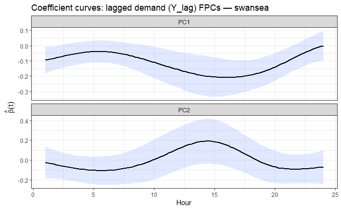

```r
extract_coef_curve <- function(term_name) {
  block <- coefs[["smterms"]][[term_name]][["coef"]]
  tibble(t = block[["yindex.vec"]], value = block[["value"]], se = block[["se"]])
}

pc_curves <- bind_rows(
  extract_coef_curve("ffpc(Y_lag)1") |> mutate(component = "PC1"),
  extract_coef_curve("ffpc(Y_lag)2") |> mutate(component = "PC2")
)

ggplot(pc_curves, aes(x = t, y = value)) +
  geom_ribbon(aes(ymin = value - 1.96 * se, ymax = value + 1.96 * se),
              fill = "#648FFF", alpha = 0.2) +
  geom_line(colour = "black", linewidth = 0.8) +
  facet_wrap(~ component, ncol = 1, scales = "free_y") +
  labs(x = "Hour", y = expression(hat(beta)(t)),
       title = sprintf("Coefficient curves: lagged demand (Y_lag) FPCs — %s", loc_study)) +
  theme_bw()
```

## 9. Predict on the test set

```r
cat("Predicting on test set...\n")
```

```
Predicting on test set...
```

```r
pred <- predict(fit,
  newdata = list(
    Y_lag     = clean_mat(test_data$Y_lag),
    temp_mean = clean_mat(test_data$temp),
    wind_mean = clean_mat(test_data$wind),
    activity  = clean_mat(test_data$activity)
  ),
  se.fit = TRUE
)

pred_mean  <- pred$fit
pred_lower <- pred$fit - 1.96 * pred$se.fit
pred_upper <- pred$fit + 1.96 * pred$se.fit
Y_test     <- clean_mat(test_data$Y)
```

## 10. Test performance (RMSE / MAE)

```r
res  <- Y_test - pred_mean
rmse <- sqrt(mean(res^2, na.rm = TRUE))
mae  <- mean(abs(res),   na.rm = TRUE)

cat(sprintf("Location: %s\n", loc_study))
```

```
Location: swansea
```

```r
cat(sprintf("RMSE: %.3f MWh\n", rmse))
```

```
RMSE: 119.622 MWh
```

```r
cat(sprintf("MAE:  %.3f MWh\n", mae))
```

```
MAE:  92.416 MWh
```

## 11. Plot predicted vs. observed curves with 95% CI

```r
plot_dir <- "loc_study"
dir.create(plot_dir, showWarnings = FALSE)

pdf(file.path(plot_dir, paste0(loc_study, "_predictions.pdf")), width = 10, height = 4)

for (j in 1:nrow(pred_mean)) {
  y_obs <- Y_test[j, ]
  y_hat <- pred_mean[j, ]
  y_lo  <- pred_lower[j, ]
  y_hi  <- pred_upper[j, ]
  ylim  <- range(c(y_obs, 0, y_hi), na.rm = TRUE)

  plot(t_grid, y_obs, type = "l", lwd = 1.5, col = "black",
       ylim = ylim, xlab = "Hour", ylab = "Demand (MWh)",
       main = paste0(tools::toTitleCase(loc_study), "  |  ", dates_test[j]))
  polygon(c(t_grid, rev(t_grid)), c(y_hi, rev(y_lo)),
          col = adjustcolor("steelblue", 0.2), border = NA)
  lines(t_grid, y_hat, col = "steelblue", lwd = 2)
  legend("topright",
         legend = c("Observed", "Predicted", "95% CI"),
         col    = c("black", "steelblue", adjustcolor("steelblue", 0.3)),
         lwd    = c(1.5, 2, 8), bty = "n", cex = 0.8)
}

dev.off()
```

```r
cat(sprintf("Saved: %s/%s_predictions.pdf\n", plot_dir, loc_study))
```

```
Saved: loc_study/swansea_predictions.pdf
```